# Your Data, Your Discoveries

PS50008A Week 12 | Research Design Framework

Gordon Wright

21 January 2026

# Welcome to Week 12

## Who Are We?

**Dr Gordon Wright**

Module Coordinator

Research: Social cognition, deception, dark personalities and interpersonal perception

Office hours: Thursdays 12:00-13:00

**Dr Bence Palfi**

Lecturer in the department and our second Lab instructor

Research: AI, Human-Computer Interactions, Meta-Science

## What Is This Module?

**Research Methods & Experimental Design**

How psychologists:

- Ask questions about the mind and behaviour
- Design studies to answer those questions
- Collect and analyse data
- Draw valid conclusions

# Why Research Methods?

## The Problem with Common Sense

- “Opposites attract”
- “Birds of a feather flock together”
- Both can’t be true… can they?

Common sense often gives contradictory answers. Science provides a systematic way to find out what’s actually true.

## Everyday Thinking vs Scientific Thinking

**Everyday Thinking**

- Based on personal experience
- Influenced by biases
- Accepts anecdotes as evidence
- Confirmation bias
- “I just know”

**Scientific Thinking**

- Based on systematic observation
- Controls for biases
- Requires replicable evidence
- Seeks disconfirmation
- “Let’s test it”

## Why Should You Care?

- Evaluate claims you encounter daily
- Understand how psychological knowledge is created
- Essential for your dissertation
- Transferable skills for any career
- Required for postgraduate study

# The Research Process

## From Question to Knowledge

```
flowchart LR
    Q[Research Question] --> H[Hypothesis]
    H --> D[Design Study]
    D --> C[Collect Data]
    C --> A[Analyse Data]
    A --> I[Interpret Results]
    I --> Q
```

## Step 1: The Research Question

Where do research questions come from?

- Curiosity about behaviour
- Gaps in existing research
- Real-world problems
- Theory testing
- Unexpected observations

**Example:** Do people lie more when texting than face-to-face?

## Step 2: The Hypothesis

A **hypothesis** is a specific, testable prediction about what you expect to find.

**Good hypothesis:**

> “Participants will tell more lies per conversation when communicating via text message compared to face-to-face.”

**Not a hypothesis:**

> “I wonder if texting affects lying.”

## Step 3: Design the Study

Key decisions:

- Who will you study? (participants)
- What will you measure? (variables)
- How will you measure it? (methods)
- What comparisons will you make? (design)

We’ll spend most of this module on this step.

## Step 4: Collect Data

- Follow your plan precisely
- Treat participants ethically
- Record everything carefully
- Minimise errors and bias

## Step 5: Analyse Data

**Statistics** are tools for finding patterns in data and determining whether those patterns are meaningful.

This is where **R** comes in — and what you’ll learn in the labs.

## Step 6: Interpret Results

- What do the findings mean?
- Do they support the hypothesis?
- What are the limitations?
- What questions remain?

Then the cycle continues…

# What You’ll Learn

## Project Timeline

| Week | Milestone |
| --- | --- |
| 11 | See how much fun collecting data is! |
| 12-15 | Develop research question and design |
| — | *Reading Week* — Work on Research Plan |
| 16 | **Research Plan due**; Begin data collection |
| 17-18 | Data collection and initial analysis |
| 19-20 | Complete analysis; Develop write-up (term ends) |
| Spring Break | Individual report writing |
| Post-term | **Research Report due** 1 May 2026 |

## Lectures vs Labs

**Lectures (Wednesday 10-12 from week 12)**

- Concepts and theory
- Research design principles
- How to think about data

**Labs (Thursday 10-12)**

- Working with real data
- Building practical skills
- Applying design principles
- Learning about statistical test with R

They work together — lecture concepts, lab application.

## Why R? (nothing to fear!)

- Free and open source
- Industry standard in data science
- Powerful data analysis and visualisation
- Reproducible research
- Employable skill

**No Experience Required**

We assume you’ve never programmed before. We start from zero.

## Assessment Overview

Find an overview here

| Assessment | Weight | Deadline | Week |
| --- | --- | --- | --- |
| Research Plan | 20% | Fri 27 Feb 2026, 12 noon | 16 |
| MCQ Exam | 20% | Wed 11 Mar 2026, in lecture slot | 18 |
| EDS Assignment | 20% | Fri 20 Mar 2026, 12 noon | 20 |
| Research Report | 40% | 1 May 2026, 12 noon | Post-term |

## Before We Begin

**Bookmark These**

- **Glossary** — Look up any unfamiliar terms
- **Self-Assessment Quizzes** — Check your understanding
- **Textbook Chapters** — Go deeper on any topic
- **Hypothes.is** — Ask questions, see classmates’ annotations
- **Assessment 1 Guidance** — Start here for your Research Plan

## Your data tell a story — let’s learn how to read it

## Today’s Learning Objectives

By the end of this lecture, you will be able to:

- Identify **Independent Variables (IV)** and **Dependent Variables (DV)** in any study
- Distinguish between **between-subjects**, **within-subjects**, and **correlational** designs
- Write **one-tailed** and **two-tailed** hypotheses
- Calculate and interpret **mean** and **standard deviation**

## The Big Idea

**Critical Week**

Today introduces **ALL** the terminology you need for your Research Plan.

Everything connects: Research Question → Variables → Design → Hypothesis

# Act 1: What Are Data?

## You generated these data (15 min)

## What Did You Actually Do Last Week?

You completed **6 tasks** plus pre/post surveys:

1. **Memory Test** (Mind Palace)
2. **Reflex Test** (Ruler catch)
3. **Time Warp** (60 second estimation)
4. **Sixth Sense** (Staring detection)
5. **Lady Luck** (Random numbers)
6. **Frontal Lob** (Throwing accuracy)

**Each task generated NUMBERS** — and numbers are what we analyse!

## You Are a Data Point - a datum

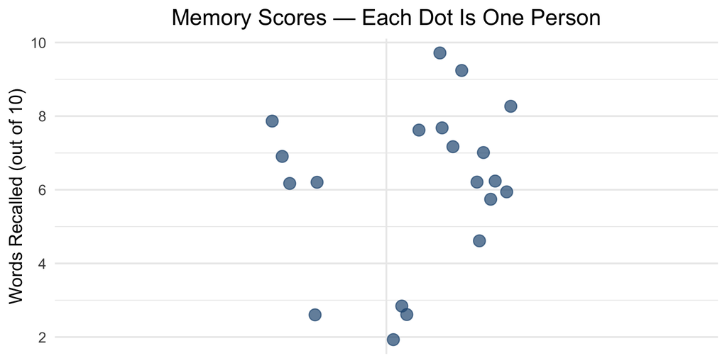

**Can you spot yourself?**

# Act 2: What’s Typical?

## The simplest question (20 min)

## When You Have Numbers, You Want to Know: What’s Normal?

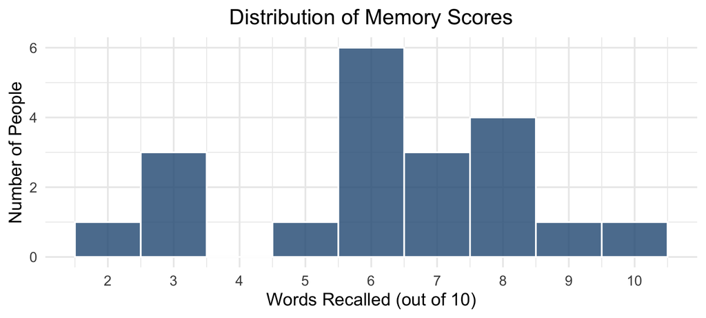

The **histogram** shows how many people got each score.

## The Mean: What’s Average?

**Mean** ($\bar{x}$) = Sum of all values ÷ Number of values

$$\bar{x} = \frac{\sum x_i}{n}$$

## That’s what I mean!

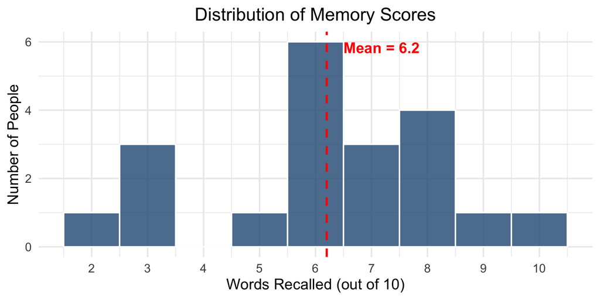

For your memory scores: **Mean = 6.2 words**

## But Wait… Same Mean, Different Stories

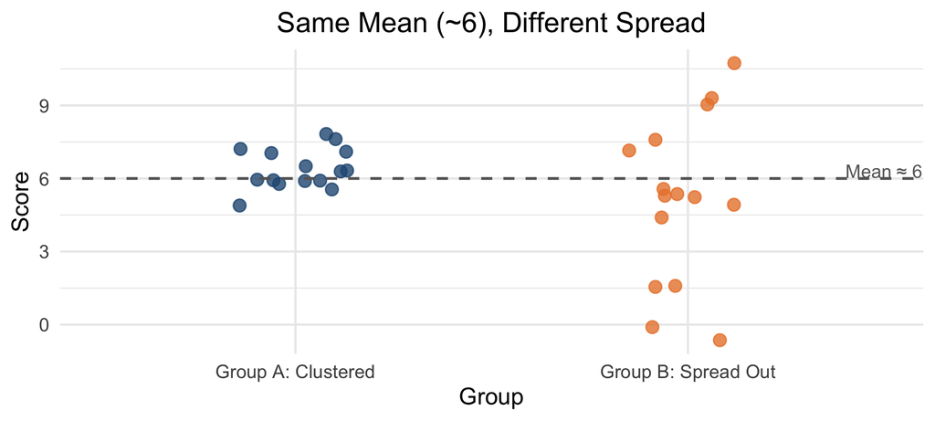

**Same mean, but Group B is much more variable!**

## We Need to Measure Spread

**Standard Deviation (SD)** = How spread out the data are from the mean

- **Low SD** = Scores clustered together (consistent)
- **High SD** = Scores spread out (variable)

For your memory scores: **SD = 2.14 words**

## The Key Insight

**Remember This**

A **difference between means** only matters if it’s **big relative to the spread**.

- **Signal** = difference between means
- **Noise** = variability within groups
- The question: Is the signal **bigger** than the noise?

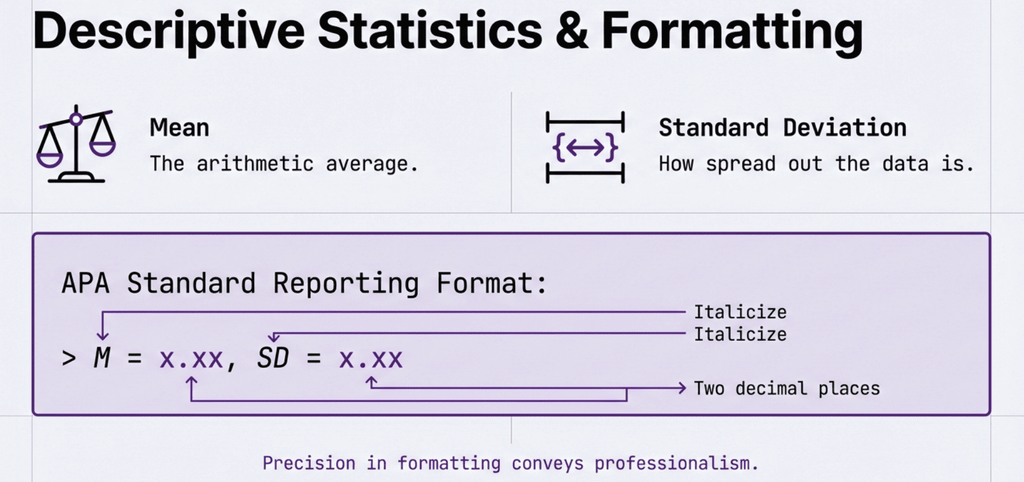

# Act 3: The Big Reveal

## Lab A vs Lab B (25 min)

## There Was a Hidden Manipulation

Last week you did the **Memory Test** (Mind Palace).

But here’s what you didn’t know…

**The Secret**

**Lab A** and **Lab B** saw **different words**!

## The Manipulation

**Lab A (Gordon)**

Memorised **abstract** words:

- Justice
- Freedom
- Wisdom
- Courage
- Truth

**Lab B (Bence)**

Memorised **concrete** words:

- Chair
- River
- Mountain
- Apple
- Hammer

## Let’s See the Results!

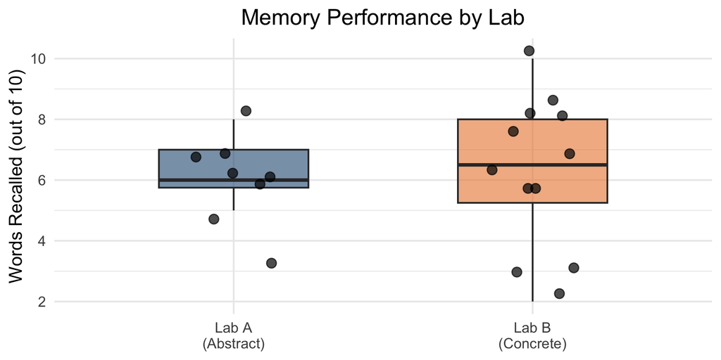

## The Numbers

| Lab | Word Type | n | Mean | SD |
| --- | --- | --- | --- | --- |
| Lab A | Abstract | 8 | 6 | 1.51 |
| Lab B | Concrete | 12 | 6.3 | 2.53 |

**Difference**: 0.3 words

Is this difference **real** or just **chance**?

Join us in week 14 and we will put that to the **t-test**!

## Now Let’s Introduce the Terminology

**Independent Variable (IV)**: What the researcher **manipulates** or controls

**Dependent Variable (DV)**: What the researcher **measures** — the outcome

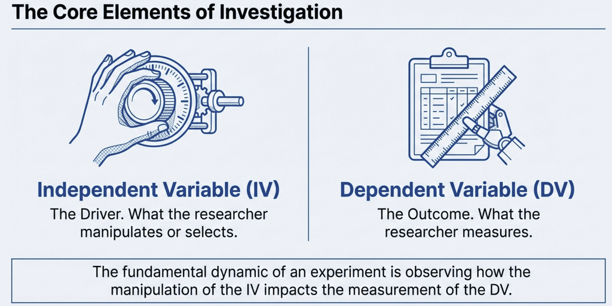

In the memory experiment:

- **IV** = Word type (abstract vs concrete)
- **DV** = Number of words recalled (0-10)

## Design Type: Between-Subjects

**Between-subjects design**: Different participants in each condition

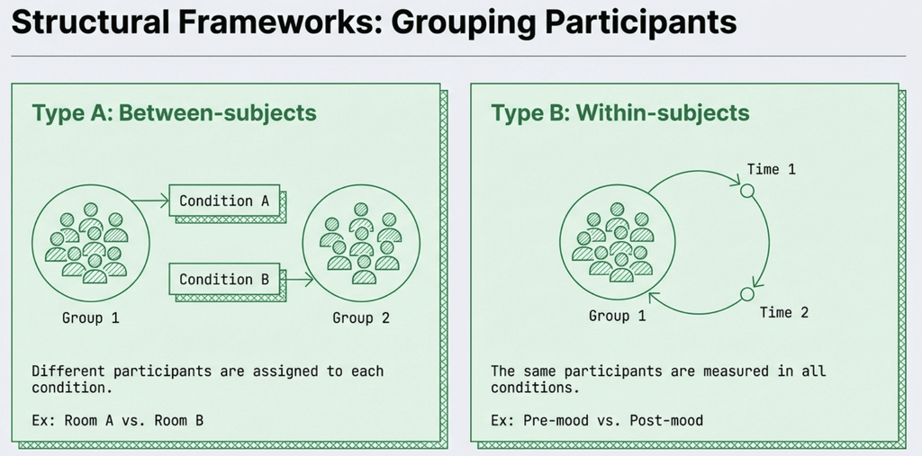

- Lab A people **only** saw abstract words
- Lab B people **only** saw concrete words
- You couldn’t be in **both** labs!

Why? **Between** = different people in each group

## Writing a Hypothesis

**Experimental hypothesis (H₁)**: Predicts an effect or difference

**Null hypothesis (H₀)**: Predicts no effect or no difference

For the memory experiment:

- **H₁**: Concrete words will be easier to remember than abstract words
- **H₀**: There will be no difference in recall between word types

## One-Tailed vs Two-Tailed

**One-tailed**: Predicts the **direction** of the effect

**Two-tailed**: Predicts a difference but **not** which direction

- **One-tailed**: “Concrete words will be **better** than abstract” (predicts direction)
- **Two-tailed**: “Word type will **affect** memory” (no direction)

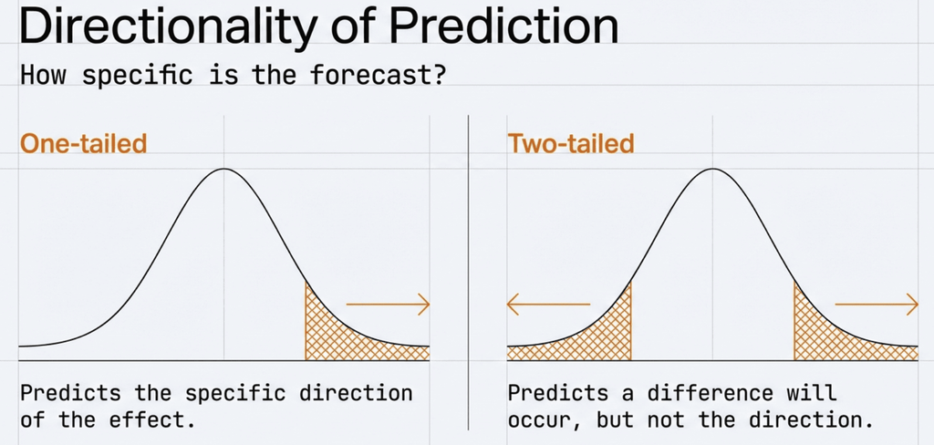

# Act 4: Same Person, Different Conditions

## Within-subjects design (20 min)

## The Pre-Post Mood Survey

Remember you rated your **mood** at the start AND end of the session?

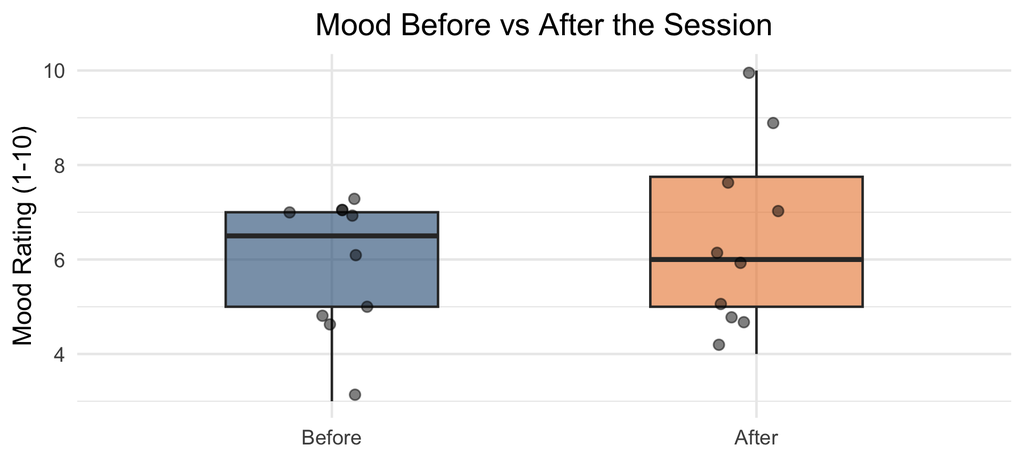

## This Is Within-Subjects Design

**Within-subjects design**: The **same participants** measured in **all conditions**

- Pre-mood and post-mood came from **the same person**
- You’re being compared **to yourself**

## Why Is This Powerful?

**The Power of Within-Subjects**

Each person is their own **control**!

Individual differences are **controlled**:

- If your pre-mood was 5 and post-mood was 7…
- **You** improved by 2 points
- We don’t need to worry about other people’s baseline moods

# Act 5: Relationships, Not Differences

## Correlational design (15 min)

## Self-Rating vs Actual Performance

Before the throwing task, you **rated** how good you thought you’d be.

**Question**: Do people know themselves?

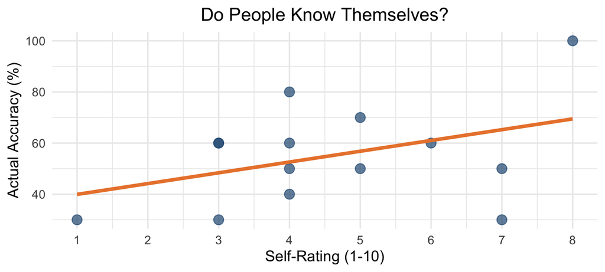

## This Is Correlational Design

**Correlational design**: Measuring the **relationship** between two variables — **no manipulation**

- **Variable 1**: Self-rating (1-10)
- **Variable 2**: Actual accuracy (%)

**Key Point**

There is **no IV** in a correlational design!

## The Critical Warning

**Say It With Me**

**Correlation ≠ Causation**

Finding a relationship does NOT mean one variable **causes** the other.

Even if self-ratings predict performance, we can’t say self-ratings **cause** good performance.

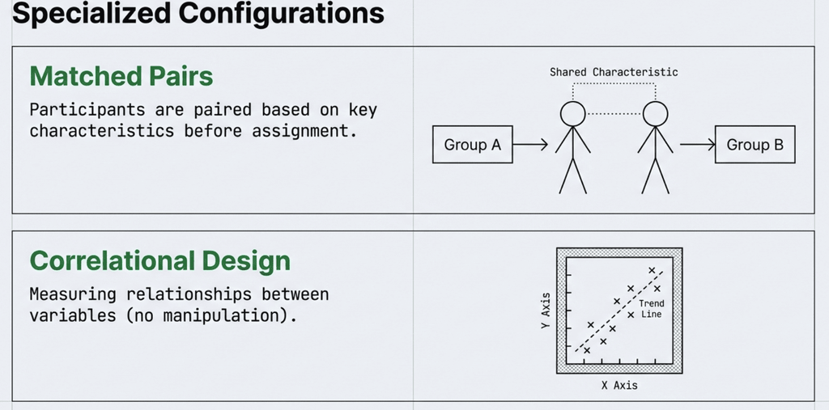

# Act 6: Was It Just Luck?

## The null hypothesis (20 min)

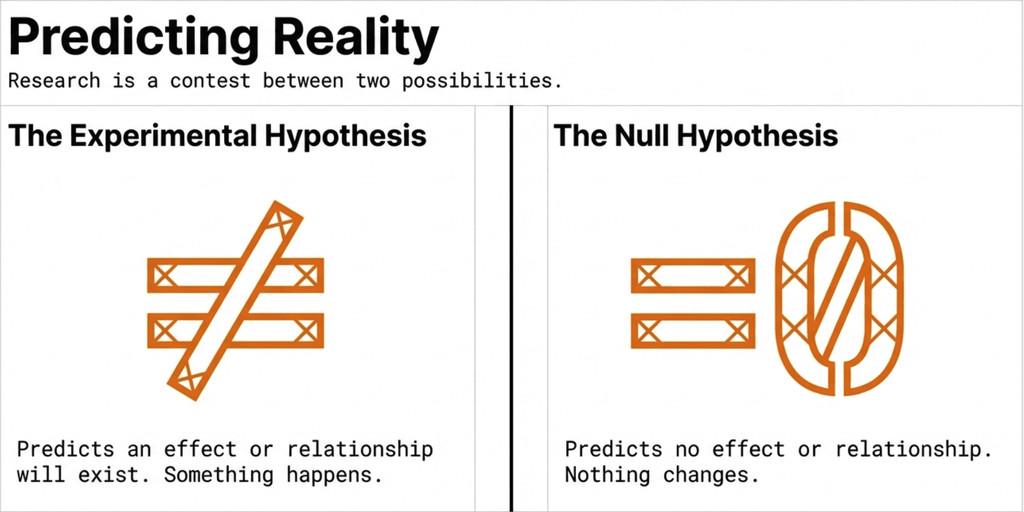

## The Sixth Sense Task

You tried to detect if someone was staring at you.

- 6 trials
- Guessed “staring” or “not staring”

**If you’re just guessing**: You’d expect **3 out of 6** right (50%)

## Your Results

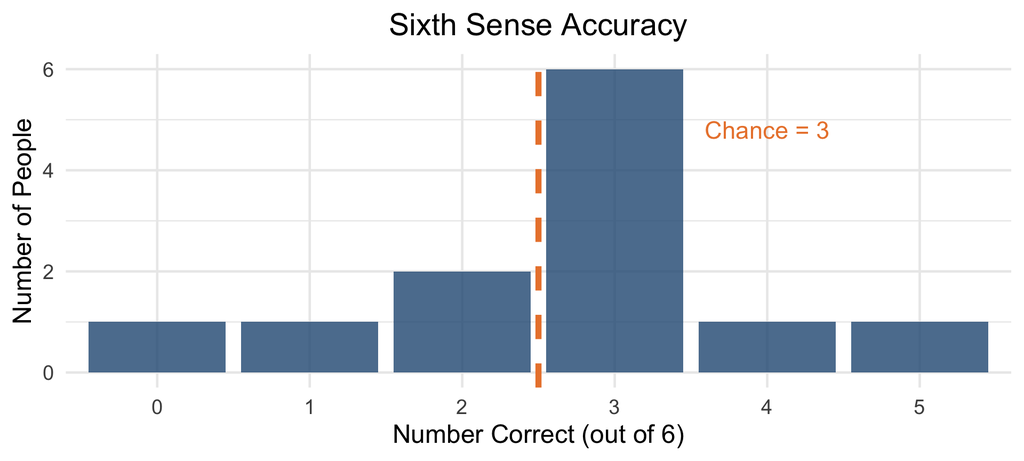

## Some People Got 5/6 or 6/6!

**The Question**

Does getting 5 or 6 right mean you have a **sixth sense**?

**Not necessarily!**

If you flip a coin 6 times, sometimes you get 5 or 6 heads **just by luck**.

## The Null Hypothesis

**Null hypothesis (H₀)**: The result is due to **chance**, not a real effect.

For the sixth sense:

- **H₀**: People are just guessing (performance = 50%)
- **H₁**: People can detect staring (performance ≠ 50%)

## Your Dice Rolls

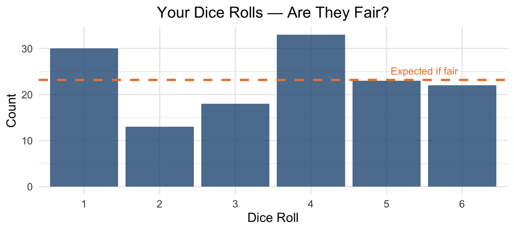

## Your Coin Flips

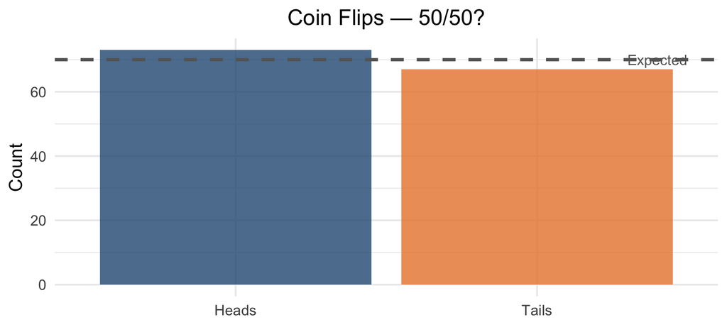

## Why Statistics?

With 20 people, **some will get lucky**:

- A few might get 5/6 or 6/6 just by chance
- Dice won’t land perfectly evenly
- Coins won’t be exactly 50/50

**Statistics helps us ask**: How surprising is this result? See week14!

# The Framework

## Putting it all together (5 min)

## The Research Design Decision Tree

**Step 1: Is there manipulation?**

- **Yes** → Experimental design
- **No** → Correlational design

**Step 2: If experimental, same or different people?**

- **Same people** → Within-subjects
- **Different people** → Between-subjects

**The Quick Check**

**No IV?** → Correlational

**IV + same people?** → Within-subjects

**IV + different people?** → Between-subjects

## DataLab Summary

| Task | Design | IV | DV |
| --- | --- | --- | --- |
| Memory | Between | Word type | Recall (0-10) |
| Pre/Post Mood | Within | Time | Rating (1-10) |
| Frontal Lob | Within | Hand | Accuracy (%) |
| Sixth Sense | vs Chance | — | Hits (0-6) |
| Self vs Actual | Correlational | — | — |

## The Vocabulary You Now Have

**Check These Off**

- Independent Variable (IV)
- Dependent Variable (DV)
- Between-subjects design
- Within-subjects design
- Correlational design
- One-tailed hypothesis
- Two-tailed hypothesis
- Null hypothesis (H₀)
- Mean and Standard Deviation

## Connecting to Assessments

| Assessment | What You Learned Today |
| --- | --- |
| **Research Plan** | ALL terminology — you can start planning! |
| **MCQ Exam** | Design identification, IV/DV, hypothesis types |
| **EDS Assignment** | Calculating means and SDs, identifying designs |
| **Research Report** | Method section structure |

## What’s Next?

**Thursday Lab**: Apply this framework to YOUR DataLab data

- Identify designs, IVs, DVs
- Calculate means and SDs
- Practice writing hypotheses

**Focus on conceptual understanding!**

# Questions?

**Remember**

- You generated this data
- Every number came from something **you** did
- The framework helps you tell the story

# See You Thursday!

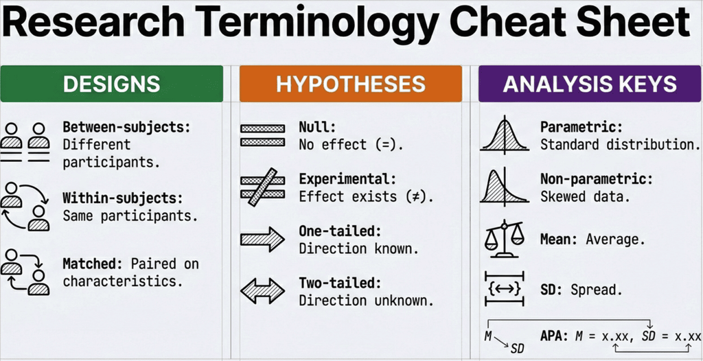